# Final Exam Data Structures

**This exam had a 3 hour time limit for completion and was completed in 2 hours and 4 minutes**

## Design

### Level 1 Design

The first level of the design involves importing the music library from a CSV file. The music library is represented as a dictionary where the keys are unique song IDs and the values are dictionaries containing song details such as title, artist, album, duration, and play count.

The song ID is generated by hashing a unique string composed of the title, artist, and album of the song. This ensures that each song has a unique ID even if there are songs with the same title but different artists or albums.

The CSV file is read using the `csv` module's `DictReader` function, which returns each row as a dictionary where the keys are the column names and the values are the cell values. This makes it easy to extract the song details and add them to the music library.

### Level 2 Design

The second level of the design involves creating playlists and adding songs to them. Playlists are also represented as dictionaries where the keys are the playlist names and the values are lists of song IDs. This allows for efficient addition and removal of songs from playlists.

Songs are added to playlists by extending the playlist's list of song IDs with a list of song IDs provided by the user. If the playlist does not exist, it is created and the song IDs are added to it.

### Level 3 Design

The third level of the design involves shuffle playing songs and searching for songs.

Shuffle play is similar to regular play, but instead of playing the songs in the order they are in the music library or playlist, the songs are shuffled using the `random.shuffle` function before they are played. This provides a randomized order of songs each time shuffle play is used.

Searching for songs involves iterating over the songs in the music library or a specific playlist and checking if the search criteria matches the song's title or artist. The search is case-insensitive to make it as user-friendly as possible. If a match is found, the song's details are printed.

## Limitations

The way you access the song IDs is admittadly a little unituitive. before you can add a song to your playlist, you have to display the songs in the library first in order to retrieve the song ID for the corresponding song. Each ID for the songs are different every time you run it so you cant just write them down one run and use them again later.

## Example of program being ran

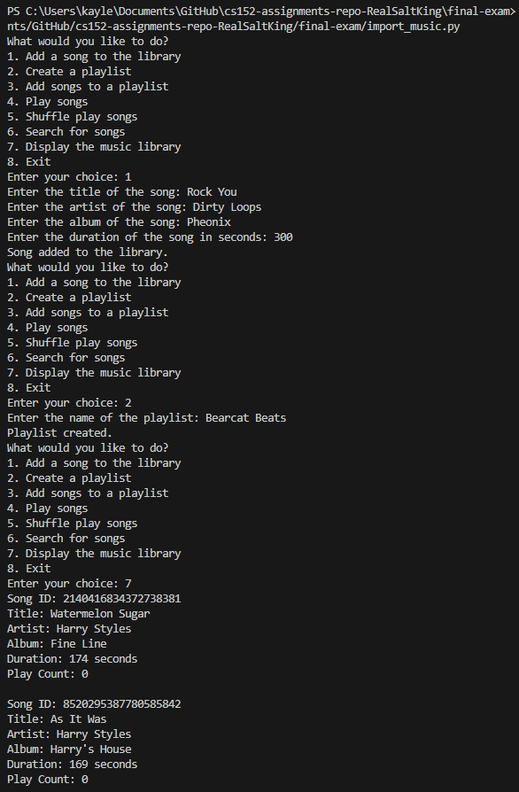

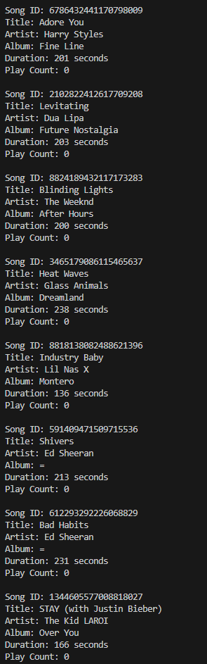

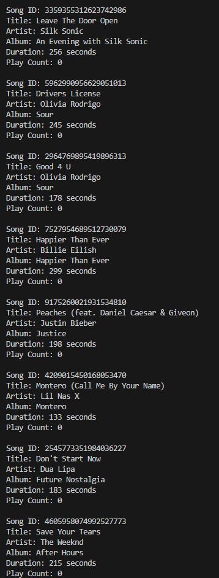

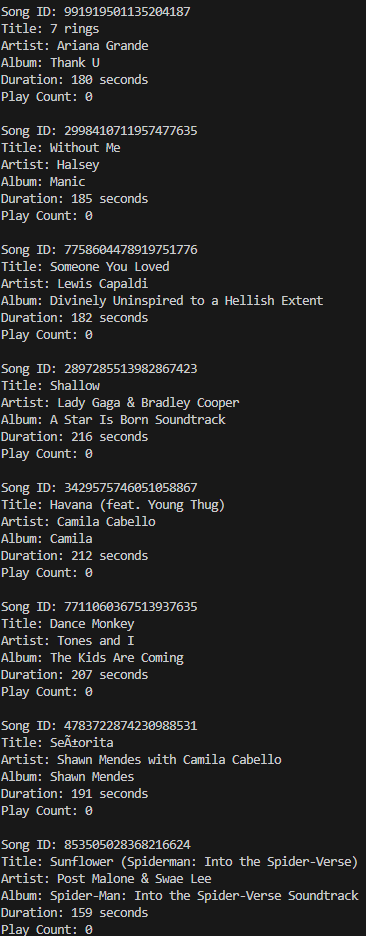

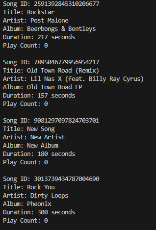

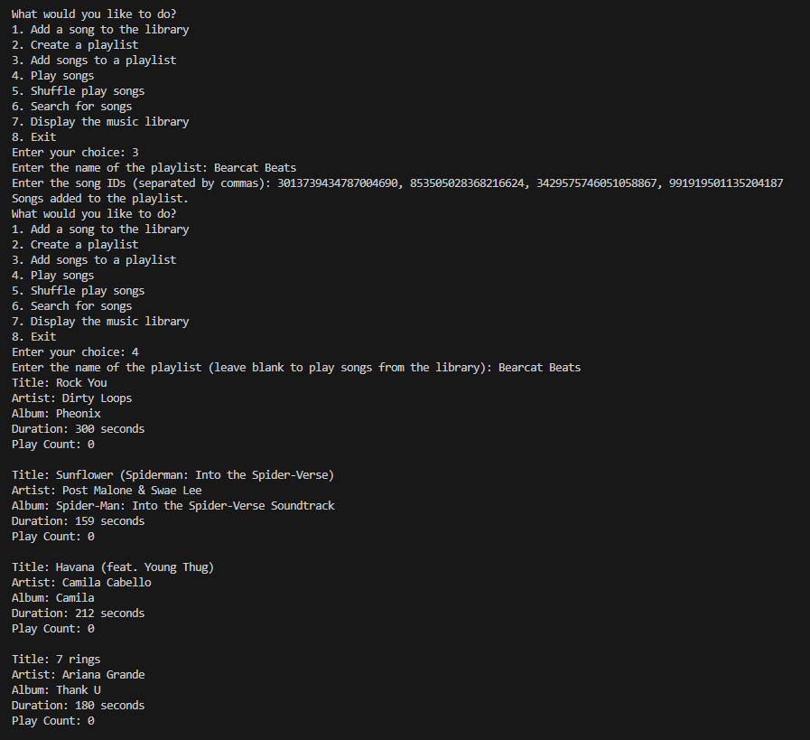

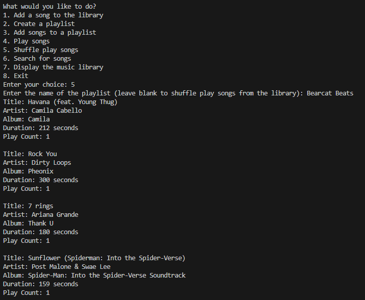

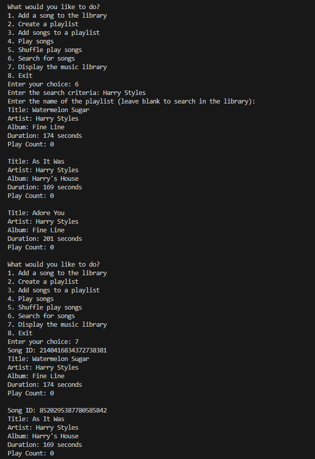

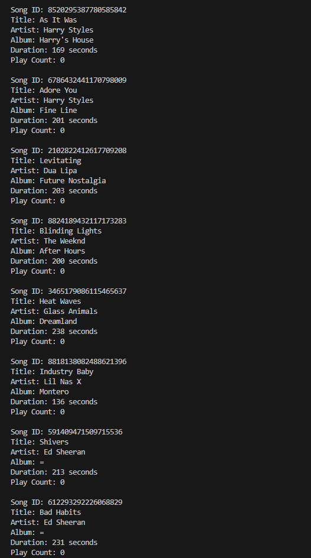

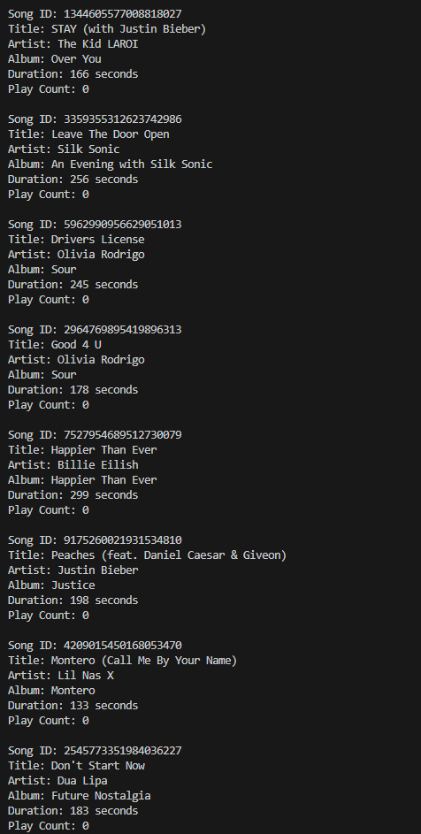

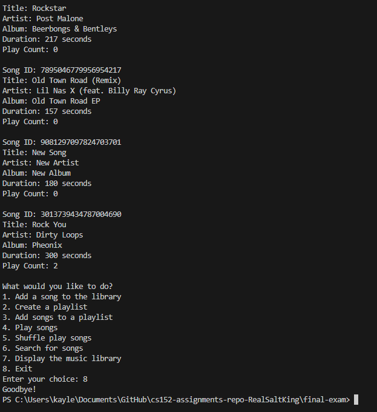

```python
import csv
import random

music_library = {}

def import_music_library(filename: str) -> None:
    with open(filename, 'r') as file:
        reader = csv.DictReader(file)
        for row in reader:
            title = row['title']
            artist = row['artist']
            album = row['album']
            duration = int(row['duration_in_seconds'])

            # Add the song to the music library
            song_id = generate_unique_id(title, artist, album)
            play_count = 0
            music_library[song_id] = {
                'title': title,
                'artist': artist,
                'album': album,
                'duration_in_seconds': duration,
                'play_count': play_count
            }

            #Uncomment for testing purposes
            #print(f"Imported song: {title} by {artist} from album {album} with duration {duration} seconds")

def add_song_to_library(title: str, artist: str, album: str, duration_in_seconds: int) -> None:
    song_id = generate_unique_id(title, artist, album)
    play_count = 0
    music_library[song_id] = {
        'title': title,
        'artist': artist,
        'album': album,
        'duration_in_seconds': duration_in_seconds,
        'play_count': play_count
    }

def display_library() -> None:
    for song_id, song_details in music_library.items():
        print(f"Song ID: {song_id}")
        print(f"Title: {song_details['title']}")
        print(f"Artist: {song_details['artist']}")
        print(f"Album: {song_details['album']}")
        print(f"Duration: {song_details['duration_in_seconds']} seconds")
        print(f"Play Count: {song_details['play_count']}")
        print()

def generate_unique_id(title: str, artist: str, album: str) -> str:
    unique_string = title + artist + album
    unique_id = hash(unique_string)
    unique_id = abs(unique_id)
    unique_id = str(unique_id)
    return unique_id

# Import music library
import_music_library('songs.csv')

# Add a song manually to the library
add_song_to_library('New Song', 'New Artist', 'New Album', 180)

# Display the music library
#display_library()

playlists = {}

def create_playlist(playlist_name: str) -> None:
    playlists[playlist_name] = []


def add_songs_to_playlist(playlist_name: str, songs: list[int]) -> None:
    if playlist_name in playlists:
        playlists[playlist_name].extend(songs)
    else:
        playlists[playlist_name] = songs


def play_songs(playlist_name: str | None=None) -> None:
    if playlist_name is None:
        # Play songs from the music library
        for song_id in music_library:
            song_details = music_library[song_id]
            print_song_details(song_details)
            increment_play_count(song_id)
    else:
        # Play songs from the specified playlist
        if playlist_name in playlists:
            playlist = playlists[playlist_name]
            for song_id in playlist:
                if song_id in music_library:
                    song_details = music_library[song_id]
                    print_song_details(song_details)
                    increment_play_count(song_id)
                else:
                    print(f"Song with ID {song_id} is not found in the music library")
        else:
            print(f"Playlist {playlist_name} does not exist")



def print_song_details(song_details: dict) -> None:
    print(f"Title: {song_details['title']}")
    print(f"Artist: {song_details['artist']}")
    print(f"Album: {song_details['album']}")
    print(f"Duration: {song_details['duration_in_seconds']} seconds")
    print(f"Play Count: {song_details['play_count']}")
    print()



def increment_play_count(song_id: str) -> None:
    if song_id in music_library:
        music_library[song_id]['play_count'] += 1



def shuffle_play(playlist_name: str | None=None) -> None:
    if playlist_name is None:
        # Shuffle play songs from the music library
        song_ids = list(music_library.keys())
        random.shuffle(song_ids)
        for song_id in song_ids:
            song_details = music_library[song_id]
            print_song_details(song_details)
            increment_play_count(song_id)
    else:
        # Shuffle play songs from the specified playlist
        if playlist_name in playlists:
            playlist = playlists[playlist_name]
            random.shuffle(playlist)
            for song_id in playlist:
                if song_id in music_library:
                    song_details = music_library[song_id]
                    print_song_details(song_details)
                    increment_play_count(song_id)
                else:
                    print(f"Song with ID {song_id} is not found in the music library")
        else:
            print(f"Playlist {playlist_name} does not exist")


def search(search_criteria: str, playlist_name: str | None=None) -> None:
    if playlist_name is None:
        # Search in the music library
        for song_id, song_details in music_library.items():
            if search_criteria.lower() in song_details['title'].lower() or search_criteria.lower() in song_details['artist'].lower():
                print_song_details(song_details)
    else:
        # Search in the specified playlist
        if playlist_name in playlists:
            playlist = playlists[playlist_name]
            for song_id in playlist:
                if song_id in music_library:
                    song_details = music_library[song_id]
                    if search_criteria.lower() in song_details['title'].lower() or search_criteria.lower() in song_details['artist'].lower():
                        print_song_details(song_details)
                else:
                    print(f"Song with ID {song_id} is not found in the music library")
        else:
            print(f"Playlist {playlist_name} does not exist")

def prompt_user() -> None:
    while True:
        print("What would you like to do?")
        print("1. Add a song to the library")
        print("2. Create a playlist")
        print("3. Add songs to a playlist")
        print("4. Play songs")
        print("5. Shuffle play songs")
        print("6. Search for songs")
        print("7. Display the music library")
        print("8. Exit")

        choice = input("Enter your choice: ")

        if choice == "1":
            add_song_prompt()
        elif choice == "2":
            create_playlist_prompt()
        elif choice == "3":
            add_songs_to_playlist_prompt()
        elif choice == "4":
            play_songs_prompt()
        elif choice == "5":
            shuffle_play_prompt()
        elif choice == "6":
            search_prompt()
        elif choice == "7":
            display_library()
        elif choice == "8":
            print("Goodbye!")
            break
        else:
            print("Invalid choice. Please try again.")

def add_song_prompt() -> None:
    title = input("Enter the title of the song: ")
    artist = input("Enter the artist of the song: ")
    album = input("Enter the album of the song: ")
    duration = int(input("Enter the duration of the song in seconds: "))

    add_song_to_library(title, artist, album, duration)
    print("Song added to the library.")

def create_playlist_prompt() -> None:
    playlist_name = input("Enter the name of the playlist: ")
    create_playlist(playlist_name)
    print("Playlist created.")

def add_songs_to_playlist_prompt() -> None:
    playlist_name = input("Enter the name of the playlist: ")
    songs = input("Enter the song IDs (separated by commas): ").split(",")
    songs = [song.strip() for song in songs]

    add_songs_to_playlist(playlist_name, songs)
    print("Songs added to the playlist.")

def play_songs_prompt() -> None:
    playlist_name = input("Enter the name of the playlist (leave blank to play songs from the library): ")
    play_songs(playlist_name)

def shuffle_play_prompt() -> None:
    playlist_name = input("Enter the name of the playlist (leave blank to shuffle play songs from the library): ")
    if playlist_name == "":
        playlist_name = None
    shuffle_play(playlist_name)


def search_prompt() -> None:
    search_criteria = input("Enter the search criteria: ")
    playlist_name = input("Enter the name of the playlist (leave blank to search in the library): ")
    if playlist_name == "":
        playlist_name = None
    search(search_criteria, playlist_name)

# Prompt the user for actions
prompt_user()
```

Github repository for project: https://github.com/Willamette-University-SCIS/cs152-assignments-repo-RealSaltKing/releases/tag/FinalExamCS152

```python
!jupyter nbconvert --to html finalexam.ipynb
```

[output not shown]